### ✅ Put your name here.

#### ✅ Put your group member names here.

# Day 13 In-Class Assignment

## Are oil and protein contents related in soybean cultivars?

[figure not shown]

In today's activity, were going to keep using the Pan-African Soybean Variety Tests (PATs) dataset from the past class. Work supported by USAID's Feed the Future Soybean Innovation Lab and by the University of Missouri Northern Soybean Breeding Program.

The **learning goals** of the assignment are to:

- Practice fitting data using the functions provided to you by the Python Packages NumPy and SciPy.
- Use your model to predict oil and protein content for other soybean cultivars.

The end goal is to reproduce the results from Figures 2 and 3c-d in [de Meyer et al. (2024)](https://doi.org/10.1002/csc2.21356)

> De Meyer, E., Prenger, E., Mahmood, A., da Fonseca Santos, M., Chigeza, G., Song, Q., Mwadzingeni, L., Mukaro, R., Chibanda, M., Mabuyaye, G., Diers, B., & Scaboo, A. (2024) [Evaluating genetic diversity and seed composition stability within Pan-African Soybean Variety Trials](https://doi.org/10.1002/csc2.21356). *Crop Science*, 64, 3272–3292.

## Assignment instructions

Work with your group to complete this assignment. Instructions for submitting this assignment are at the end of the notebook. The assignment is due at the end of class.

### Loading and viewing the data

Import the necessary libraries and then load the data as usual.

```python
# Your imports
```

```python
# Code to load the PATs dataset with pandas
```

```python
# ANSWER

# Although there are some exceptions, it is generally a good idea to keep all of your
# imports in one place so that you can easily manage them. Doing so also makes it easy
# to copy all of them at once and paste them into a new notebook you are starting.

import matplotlib.pyplot as plt
import numpy as np
import os
import pandas as pd
from scipy import stats
from numpy.polynomial.polynomial import Polynomial

# Setting up source and destination directories

source = '..' + os.sep + 'raw' + os.sep
dest = '..' + os.sep + 'results' + os.sep

# Loading the CSV

filename = 'PATSA_final_QCd_rep_data.csv'

# Load data and have a few prints to make sure it is loading correctly

data = pd.read_csv(source + filename)
print('The dataset contains', data.shape[0], 'rows and', data.shape[1], 'columns.')
data = data.dropna(axis='index', how='any', subset=['PROTEIN_g/kg', 'OIL_g/kg'])
print('', data.shape[0], 'rows and', data.shape[1], 'columns after dropping NaNs')
data.head(5)
```

```
The dataset contains 306 rows and 14 columns.
 278 rows and 14 columns after dropping NaNs
```

|  | GEN | REP | BLOCK | ENV | site | Elevation_M | Soil_pH | Soil_Na | Avg_temp | Cum_precip | PROTEIN_g/kg | OIL_g/kg | Country_of_Origin | Soil_Type |
| --- | --- | --- | --- | --- | --- | --- | --- | --- | --- | --- | --- | --- | --- | --- |
| 0 | BIMHA | 1 | 5 | ENV1 | CBI-Site 4 | 421 | 8.3 | 156 | 23.3 | 64.1 | 319.3 | 236.8 | Zimbabwe | Chromic Luvisols |
| 1 | BIMHA | 2 | 9 | ENV1 | CBI-Site 4 | 421 | 8.3 | 156 | 23.3 | 64.1 | 370.9 | 219.3 | Zimbabwe | Chromic Luvisols |
| 2 | KALEYA | 1 | 4 | ENV1 | CBI-Site 4 | 421 | 8.3 | 156 | 23.3 | 64.1 | 396.3 | 213.9 | Zambia | Chromic Luvisols |
| 3 | KALEYA | 2 | 6 | ENV1 | CBI-Site 4 | 421 | 8.3 | 156 | 23.3 | 64.1 | 378.6 | 219.3 | Zambia | Chromic Luvisols |
| 4 | LUKANGA | 1 | 3 | ENV1 | CBI-Site 4 | 421 | 8.3 | 156 | 23.3 | 64.1 | 364.8 | 219.5 | Zambia | Chromic Luvisols |

### Linear Regression

As a first pass, your goal is to produce a fit to the data using a linear model. What NumPy function can you use to do this? You should be able to use something that you learned in the pre-class assignment.

**Task**: Create a linear fit to the oil versus protein content using a function from NumPy. **Make a plot of the data along with the best fit line**. What are the parameters for your best fit? Print out those parameter values and incorporate them in the plot. Are they close to the ones shown in Figure 2?

To plot the best fit curve:

- Define **domain** $x$-axis values `x_pred` with NumPy `linspace`, from the minimum to maximum $x$ (protein content) values.
- Use these `linspace` values to predict $y$-axis values based on your best-fit curve.
- Plot the curve with these $x$ and $y$ values.

```python
# Put your code here
```

```python
x,y = data['PROTEIN_g/kg'], data['OIL_g/kg']

poly = Polynomial.fit(x,y, 1)
pred_oil = poly(x)
b,m  = poly.convert().coef
print(b,m)
```

```
375.6035236142795 -0.4446523976391686
```

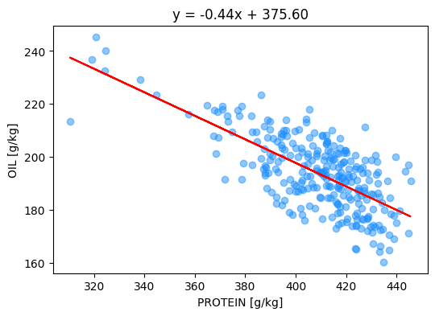

```python
fig, ax = plt.subplots(1,1, figsize=(6,4))

ax.scatter(x,y, c='dodgerblue', alpha=0.5)
ax.plot(x, pred_oil, c='r')
ax.set_ylabel('OIL [g/kg]')
ax.set_xlabel('PROTEIN [g/kg]')
ax.set_title('y = {:.2f}x + {:.2f}'.format(m,b))
```

### Higher order fitting

**Task**: Now try fitting the data with a higher order polynomial function. How would you determine how many powers are "enough"? Choose how many powers you want to include in your fit and plot.

```python
# Put your code here
```

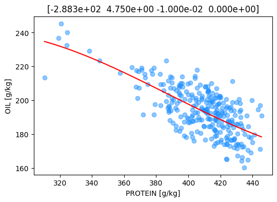

```python
poly = Polynomial.fit(x,y, 3)
pred_x = np.linspace(x.min(), x.max(), 100)
pred_y = poly(pred_x)

fig, ax = plt.subplots(1,1, figsize=(6,4))

ax.scatter(x,y, c='dodgerblue', alpha=0.5)
ax.plot(pred_x, pred_y, c='r')
ax.set_ylabel('OIL [g/kg]')
ax.set_xlabel('PROTEIN [g/kg]')
ax.set_title(np.round(poly.convert().coef, 2));
```

### Dangers of polynomial fitting

Be careful with polynomial curves: they tend to overfit the data. That is, the curve will appear to follow very closely your data, but it will have erratic/unexpected results for large or small $x$-values (outside your data domain, to be more precise.)

For example, change `x_pred = np.linspace(x.min(), x.max())` to `x_pred = np.linspace(300, 500)`. Or what about from 100 to 700? How does the curve look now? Would you trust the curve?

```python
# Put your code here
```

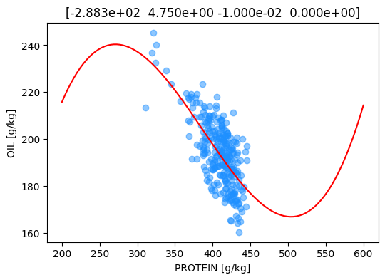

```python
pred_x = np.linspace(200, 600, 100)
pred_y = poly(pred_x)

fig, ax = plt.subplots(1,1, figsize=(6,4))

ax.scatter(x,y, c='dodgerblue', alpha=0.5)
ax.plot(pred_x, pred_y, c='r')
ax.set_ylabel('OIL [g/kg]')
ax.set_xlabel('PROTEIN [g/kg]')
ax.set_title(np.round(poly.convert().coef, 2));
```

## Comparing our fit to new data

One of the useful features of coming up with a best fit model to a set of data is that we can use that model to make predictions about what new data might look like.

**Task**: Using your linear fit and another best fit of your choosing, make a plot that predicts the oil content for soybean grains with very high or very low protein content. Say, what would be the expected oil content of a soybean grain that has 500g of protein? What about only 250g of protein?

```python
# Put your code here
```

```python
poly = Polynomial.fit(x,y, 1)

for val in [250,500]:
    print('A variety with {} g/kg of protein will have around {:.1f} g/kg of oil.\n'.format(val, poly(val)))
```

```
A variety with 250 g/kg of protein will have around 264.4 g/kg of oil.

A variety with 500 g/kg of protein will have around 153.3 g/kg of oil.
```

We can also reverse the question: if we are seeking for a cultivar such that its grains have 300g of oil per kg, what would be the expected protein content of these grains? What about 150g/kg?

To answer this, one way is to invert the fit to do protein versus oil content.

```python
# Put your code here
```

```python
poly = Polynomial.fit(y,x, 1)
for val in [300,150]:
    print('A variety with {} g/kg of oil will have around {:.1f} g/kg of protein.\n'.format(val, poly(val)))
```

```
A variety with 300 g/kg of oil will have around 292.0 g/kg of protein.

A variety with 150 g/kg of oil will have around 456.7 g/kg of protein.
```

### How well do our models do?

Now compute the Pearson correlation coefficient of oil versus protein content. Is it close to the value reported in Figure 2? Does the value make sense compared to the plot?

```python
# Put your code here
```

```python
stats.pearsonr(x,y)
```

```
PearsonRResult(statistic=-0.6987297987578558, pvalue=4.8782824583231806e-42)
```

### Completing the picture with elevation (time permitting)

Now do a plot with *two* subplots. One for elevation versus protein content. Another for elevation versus oil content. Your goal is to produce the plots in Figure 3(c) and Figure 3(d) respectively from the source paper.

```python
# Put your code here
```

*Put your answer here*

### Congratulations, you're done!

Submit this assignment by uploading it to the course Canvas web page. Go to the "Assignments" folder, find the appropriate submission folder link, and upload it there.

© Copyright 2025, Division of Plant Science & Technology—University of Missouri